# Patient Health Data Analysis by Doug Waxler

### Introduction

The following data analysis will look at the diagnoses of patients with and  
without heart disease. I will examine the data set, look at ranges of values and look for outliers. I will also check for correlation between variables.

> For this analysis I loaded ggplot2, corrgram for correlation plotting, and knitr for printing tables cleanly.

# Univariate Plots

#### I’ll start by looking at the columns and a few rows.

```
##  [1] "Age"            "Sex"            "ChestPainType"  "RestingBP"
##  [5] "Cholesterol"    "FastingBS"      "RestingECG"     "MaxHR"
##  [9] "ExerciseAngina" "Oldpeak"        "ST_Slope"       "HeartDisease"
```

| Age | Sex | ChestPainType | RestingBP | Cholesterol | FastingBS | RestingECG | MaxHR | ExerciseAngina | Oldpeak | ST_Slope | HeartDisease |
| --- | --- | --- | --- | --- | --- | --- | --- | --- | --- | --- | --- |
| 40 | M | ATA | 140 | 289 | 0 | Normal | 172 | N | 0.0 | Up | 0 |
| 49 | F | NAP | 160 | 180 | 0 | Normal | 156 | N | 1.0 | Flat | 1 |
| 37 | M | ATA | 130 | 283 | 0 | ST | 98 | N | 0.0 | Up | 0 |
| 48 | F | ASY | 138 | 214 | 0 | Normal | 108 | Y | 1.5 | Flat | 1 |
| 54 | M | NAP | 150 | 195 | 0 | Normal | 122 | N | 0.0 | Up | 0 |

Here is the summary of the values of each variable. There are 12 characteristics for each patient.

```
##       Age            Sex            ChestPainType        RestingBP
##  Min.   :28.00   Length:918         Length:918         Min.   :  0.0
##  1st Qu.:47.00   Class :character   Class :character   1st Qu.:120.0
##  Median :54.00   Mode  :character   Mode  :character   Median :130.0
##  Mean   :53.51                                         Mean   :132.4
##  3rd Qu.:60.00                                         3rd Qu.:140.0
##  Max.   :77.00                                         Max.   :200.0
##   Cholesterol      FastingBS       RestingECG            MaxHR
##  Min.   :  0.0   Min.   :0.0000   Length:918         Min.   : 60.0
##  1st Qu.:173.2   1st Qu.:0.0000   Class :character   1st Qu.:120.0
##  Median :223.0   Median :0.0000   Mode  :character   Median :138.0
##  Mean   :198.8   Mean   :0.2331                      Mean   :136.8
##  3rd Qu.:267.0   3rd Qu.:0.0000                      3rd Qu.:156.0
##  Max.   :603.0   Max.   :1.0000                      Max.   :202.0
##  ExerciseAngina        Oldpeak          ST_Slope          HeartDisease
##  Length:918         Min.   :-2.6000   Length:918         Min.   :0.0000
##  Class :character   1st Qu.: 0.0000   Class :character   1st Qu.:0.0000
##  Mode  :character   Median : 0.6000   Mode  :character   Median :1.0000
##                     Mean   : 0.8874                      Mean   :0.5534
##                     3rd Qu.: 1.5000                      3rd Qu.:1.0000
##                     Max.   : 6.2000                      Max.   :1.0000
```

Looking at the data, a few things are noteworthy. Ages range between 28 and 77, with median age at 54. Systolic blood pressure ranged to 200, but has a minimum of 0 which may be an outlier.

Max cholesterol ratings of 603 is a sign of hypercholesterolemia, which is a strong factor in heart disease and results in total cholesterol levels typically between 300-600. This will be a good correlation to check.

Heart rates range between 60 and 202, which seems reasonable, and the max in this category may have been taken in an urgent situation for the patient.

For Fasting Blood Sugar, I had to research the data presented. In this case, a 1 represents a fasting blood sugar greater than 120 mg/dl. A 0 would indicate that fasting blood sugar was less than or equal to 120.

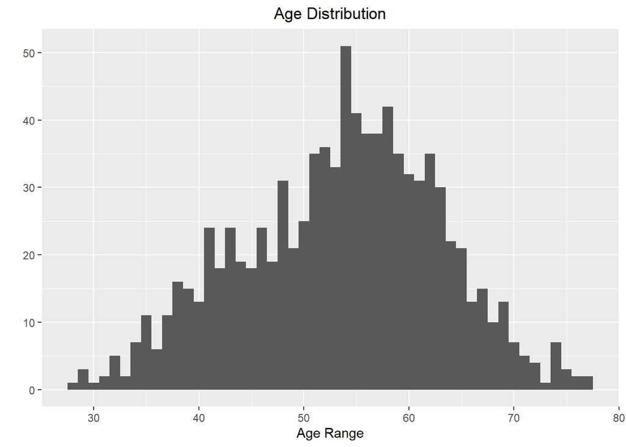

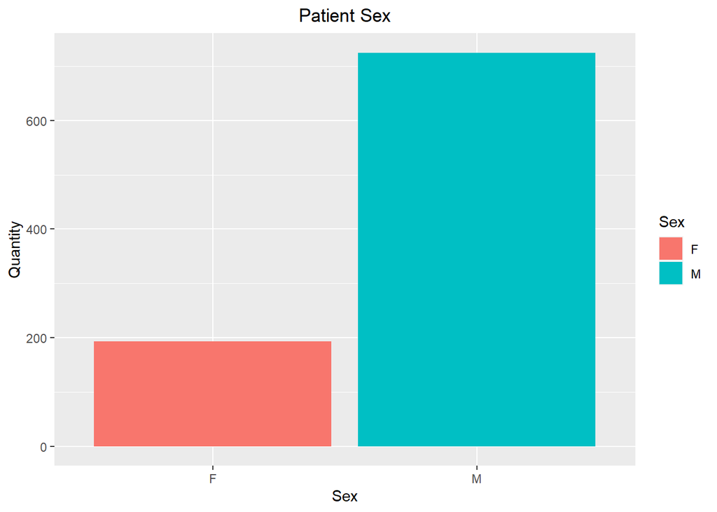

Patient gender (sex) of the dataset is heavily weighted toward males.

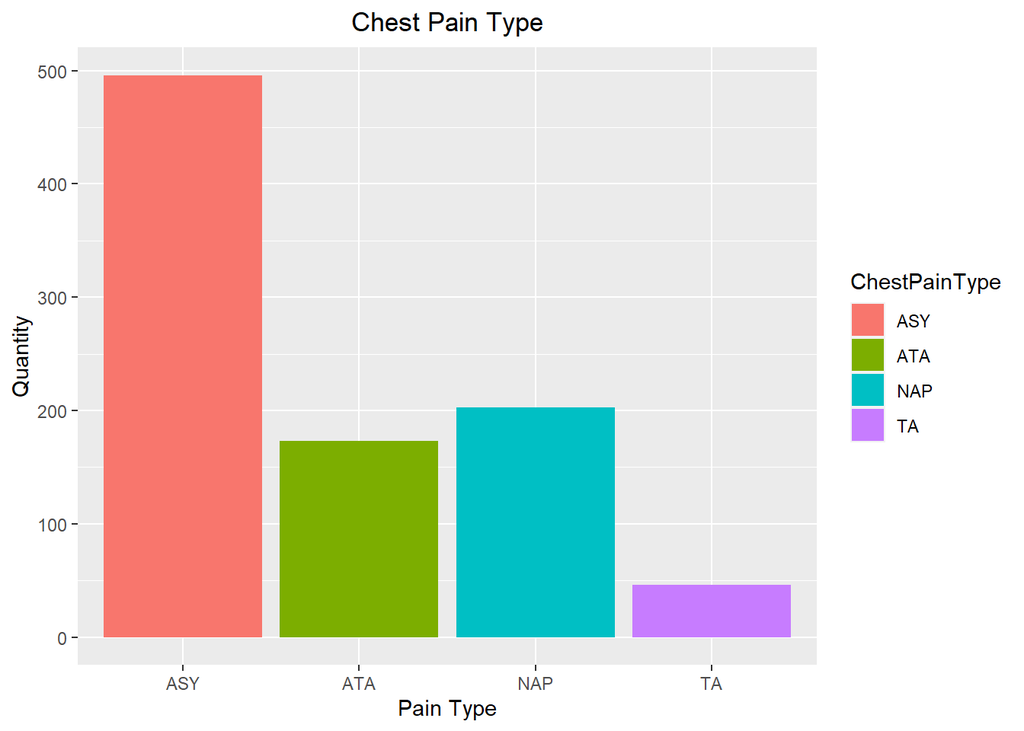

Chest pain types for the audience are broken into 4 types.

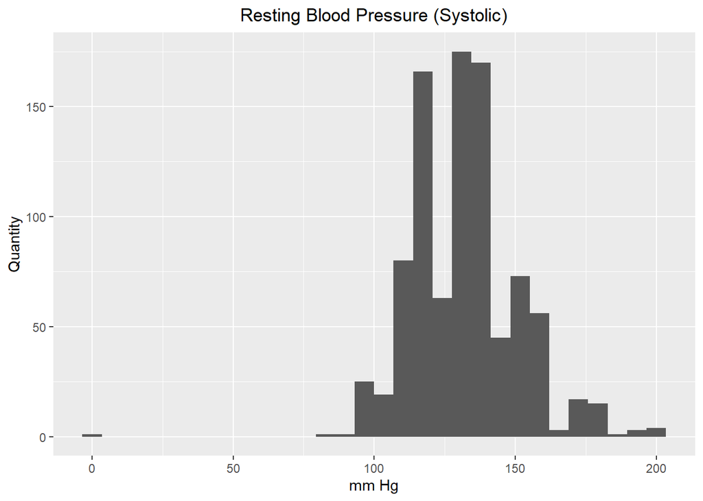

Resting blood pressure of patients admitted seems to be heavily weighted between 125-150, with a moderate portion of patients also near the ideal range, or near 120.

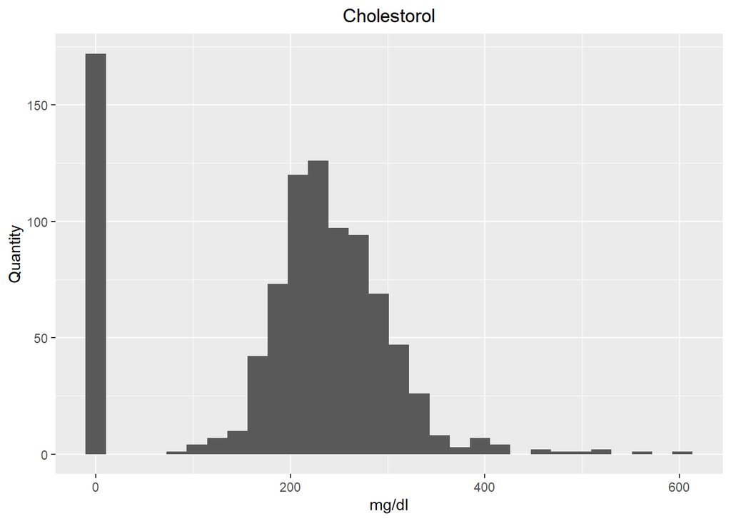

It seems a lot of folks may not have had cholesterol checked upon admission to the emergency room, for the patients in this data set.

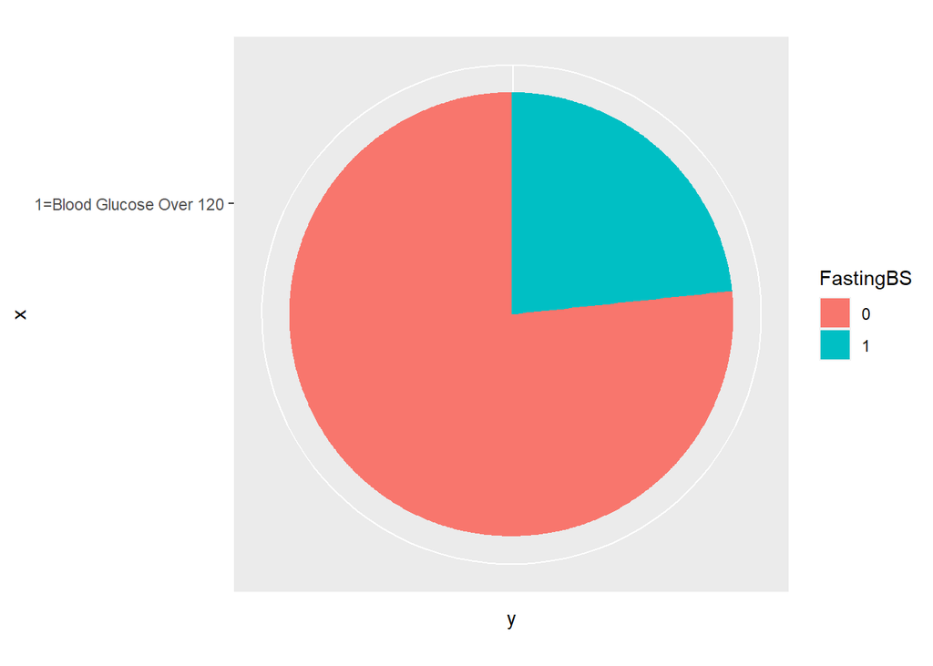

This chart shows that over 3/4 of patients did not have a fasting blood sugar over 120 mg/dl.

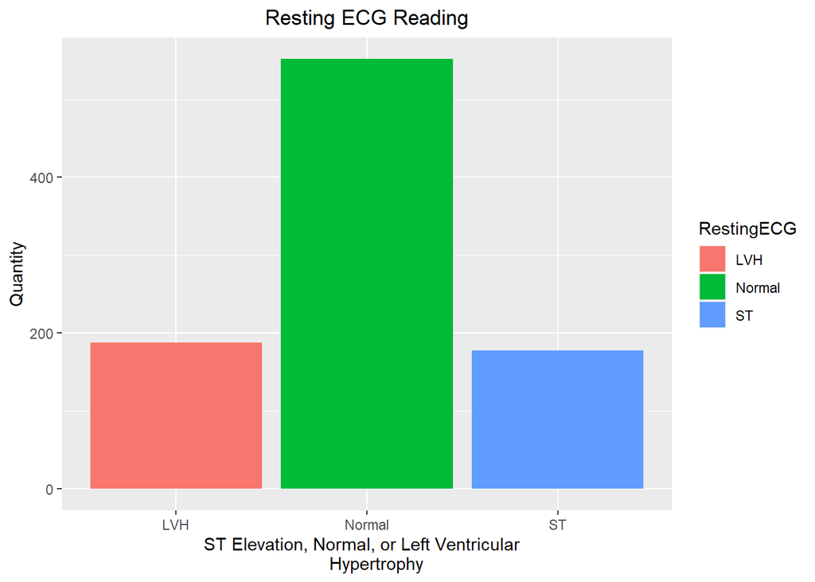

Left ventricular hypertrophy, or LVH, is a term for a heart’s left pumping chamber that has thickened and may not be pumping efficiently. Sometimes problems such as aortic stenosis or high blood pressure overwork the heart muscle. (https://www.heart.org/en/health-topics/heart-valve-problems-and-disease/\  
heart-valve-problems-and-causes/what-is-left-ventricular-hypertrophy-lvh)

To summarize, non-ischemic causes of ST-segment elevation include left ventricular hypertrophy, pericarditis, ventricular-paced rhythms, hypothermia, hyperkalemia and other electrolyte imbalances, and left ventricular aneurysm. (https://www.medscape.com/answers/155919-15140/what-are-the-non-ischemic-\  
causes-of-st-segment-elevation)

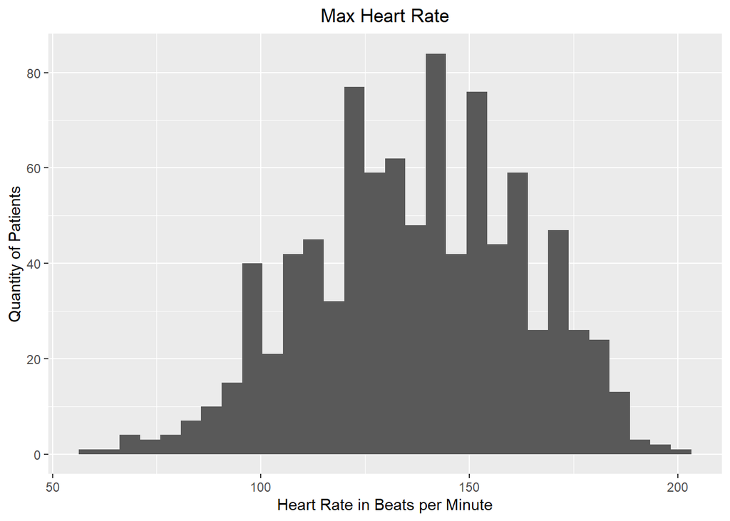

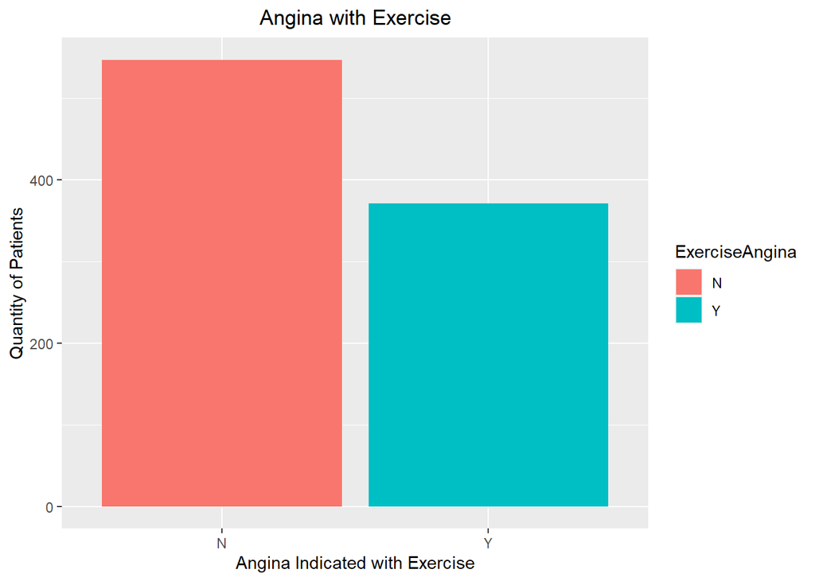

Chest pain (angina) with exercise was only present in less than half of the total patient sample.

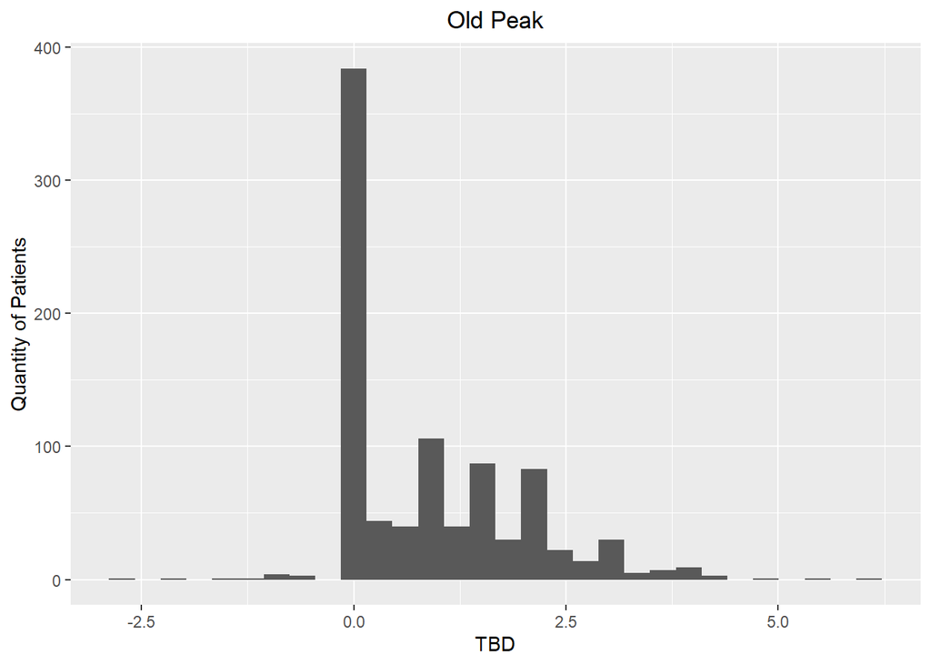

Old Peak represents a level of ST elevation in patients. It seems many had high (up) or low (down), or flat slops, but aside from Flat (0), it seems the bulk of patients’ “old peak” values are between 0 and 2.5, concentrated near 1.25 to 2.

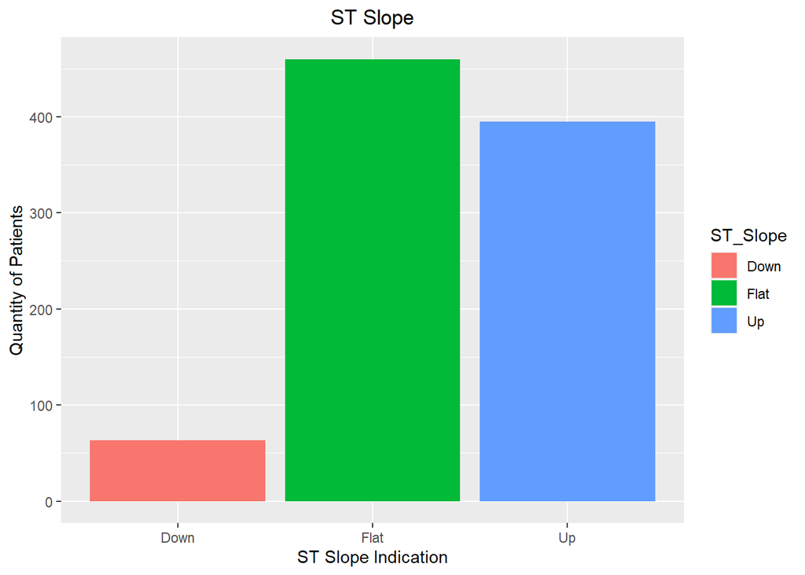

ST Slope clearly was found to be flat in the majority of admitted patients. Up slopes were second, and we will later compare how this relates to heart disease diagnosis and other variables in the dataset.

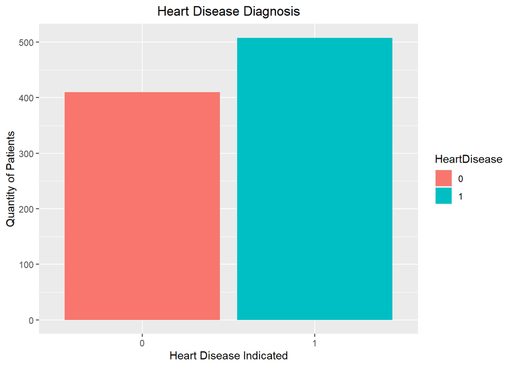

# Univariate Analysis

There are a 918 patients in the dataset with the following statistics observed: * Age - Age of the pateint * Sex - Sex/gender of the patient * ChestPainType - ATA - Atypical angina, or other non-cardiac chest pain NAP - Non-anginal pain, or non-cardiac chest pain such as esophageal ASY - Asymptomatic, or not showing signs TA - Typical Angina, chest pain is related to decreased blood supply * RestingBP - Blood Pressure in mm Hg upon admission, 130-140 is cause for  
concern * Cholesterol - Serum cholesterol in mg/dl * FastingBS - 0 or 1, 1 indicates fasting blood sugar > 120 mg/dl * RestingECG - Normal, ST, LVH - ST elevation, or left ventricular hypertrophy * MaxHR - Max heart rate achieved * ExerciseAngina - Pain (angina) upon exercise * Oldpeak - ST * ST_Slope - Upslope, downslope, or flat/no slope during exercise * HeartDisease - 1 or 0, indicating heart disease diagnosis (1=yes)

Some of the main features in the dataset seem to be Max Heart Rate, with a fairly normal distribution overall, as well as Resting ECG readings, ST Slope, and of course the heart disease diagnosis indications.

We will plot correlations between variables to see how these things relate.

Resting ECG readings and ST Slopes will be an interesting comparison as well.

# Bivariate Plots

I’d like to start by examining the correlation among all the variables. In this chart the darker blue indicates strong correlation, whereas darker red indicates negative correlation between the variables.

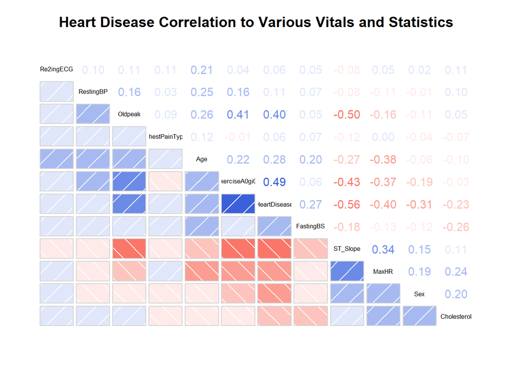

This plot shows us that strong relationships exist between heart disease diagnosis, and exercise angina. Additionally, slightly weaker but still strong correlations exist between Heart Disease and “Oldpeak”, and age is still a considerable factor.

Negative correlations seem to exist strongly between Heart Disease and ST Slope as well as MaxHR (Max Heart Rate). We will do some bivariate analysis amongst these variables.

> Next we’ll examine the relationships between a few variables, particularly  
> some that I hypothesize will relate to a heart disease diagnosis strongly, based on the correlation plot above.

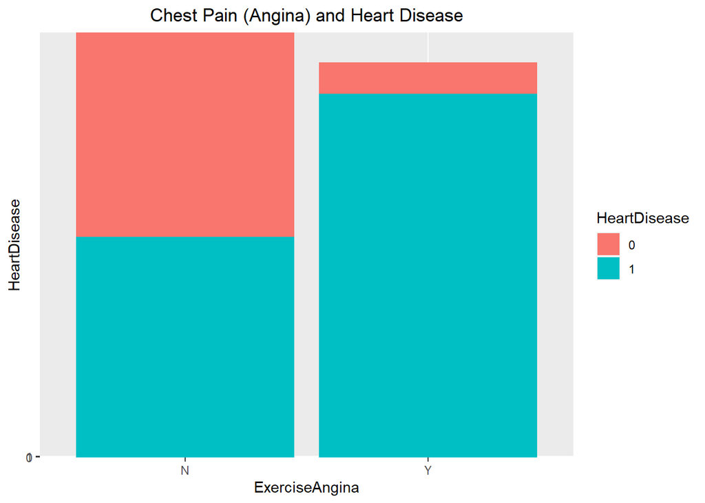

From this comparison, you can draw a couple different conclusions. First, for patients where Exercise Angina was not present, approximately half were diagnosed with heart disease. For patients who did complain of exercise angina, the vast majority did in fact end with a diagnosis of heart disease. This proves a correlation skewed toward the diagnosis of heart disease and the presence of exercise angina.

Looking at the number of non-diagnosed patients, the majority did not experience exercise angina. Unfortunately this factor alone also proves to not be a solid and reliable indicator alone. We will compare additional variables.

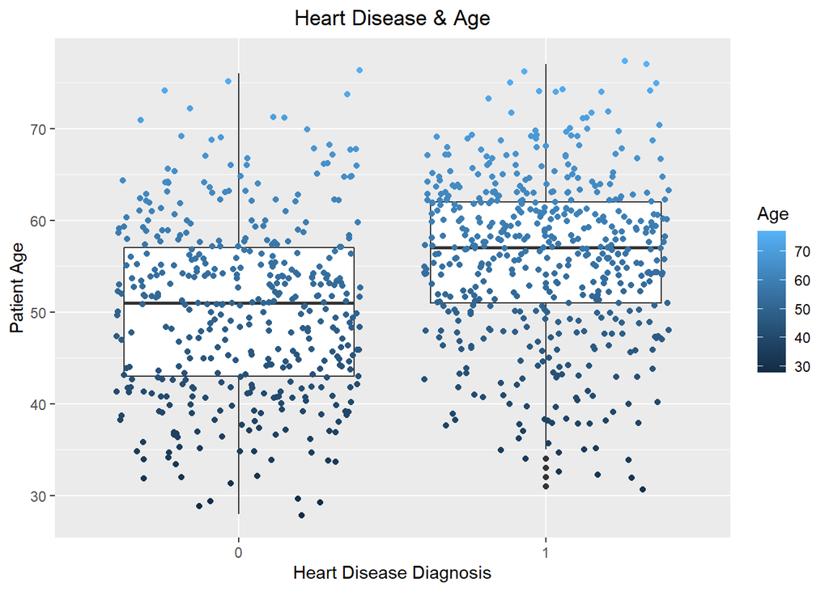

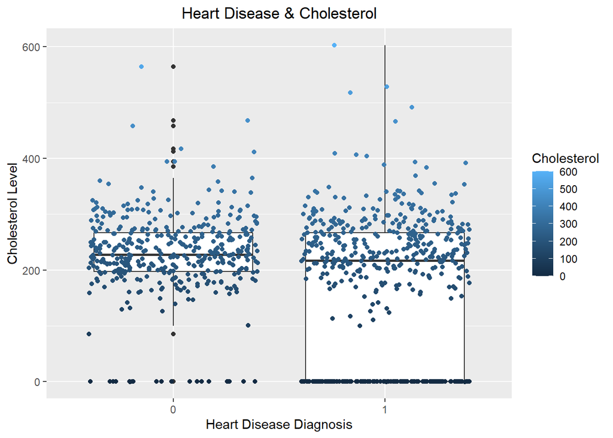

In this chart, it becomes evident that a lot of patients likely did not have their cholesterol checked upon admission, or during their hospital visit. This skews the boxplot for both positive and negative diagnosis of heart disease. I’ll attempt to ignore the zeroes and view the remainder.

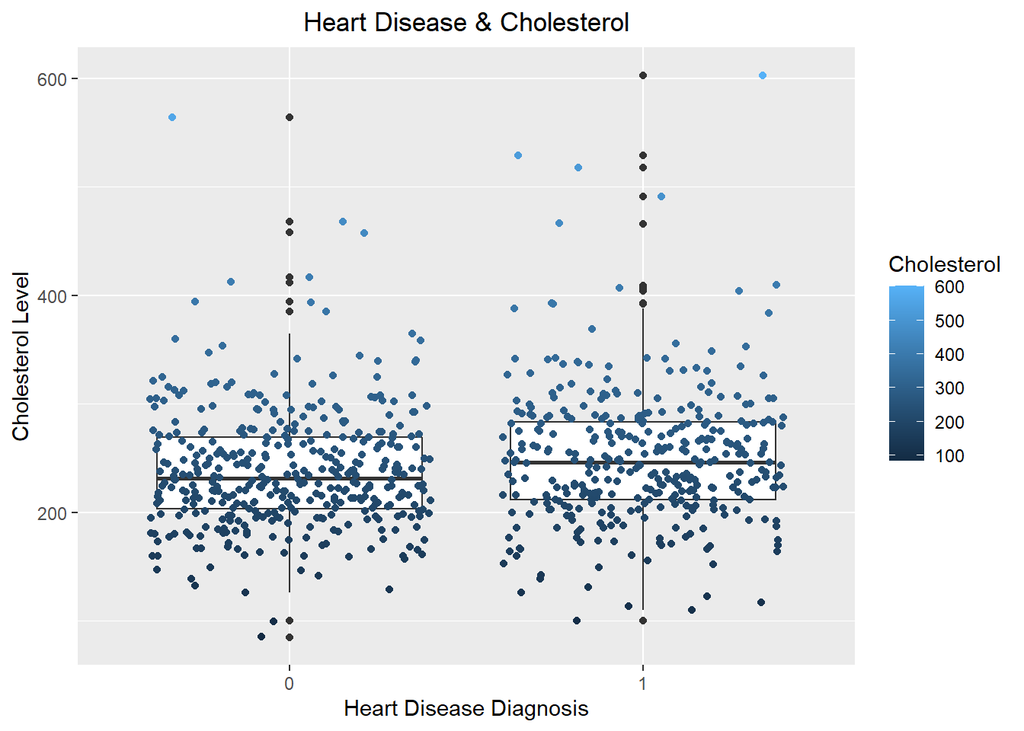

Heart disease patients’ cholesterol levels don’t seem to vary much from those who were not diagnosed. The median is only slightly higher, and the interquartile range slightly higher for cholesterol levels in positively diagnosed patients.

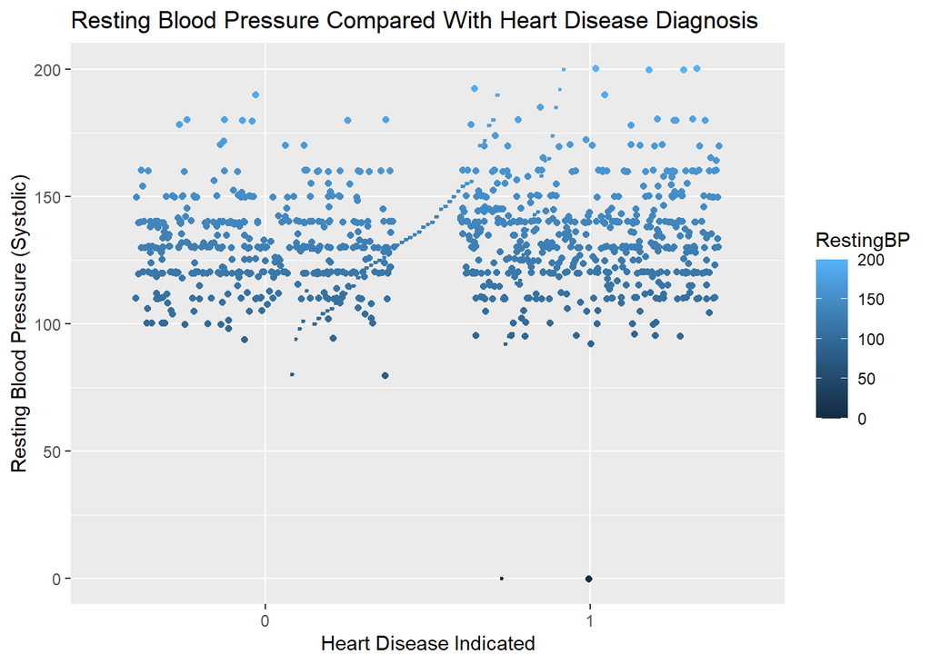

It’s interesting to see the lack of significant difference in the Resting Blood pressure of patients who were or were not diagnosed with heart disease. It looks like the upper and lower limits align with what you’d expect, the most extreme of them tending toward a positive diagnosis, and the lesser on the 0 or negative diagnosis side.

> Since sex/gender are often cited as having a different likelihood for certain medical conditions, we’ll compare gender and heart disease diagnoses as well.

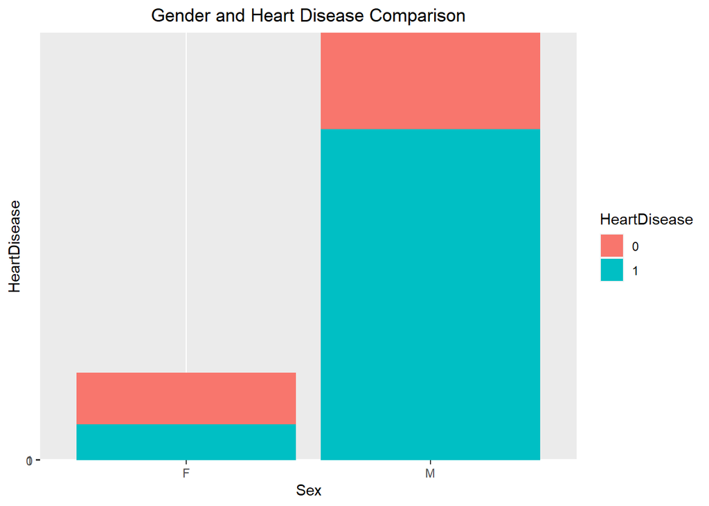

# Bivariate Analysis

For patients with heart disease and for those without, we compared several factors to see if they were weighted heavily for or against the diagnosis.

Exercise Angina was much greater in patients with heart disease. Though slighly higher, age was only a moderate factor. Ages did average higher in positively diagnosed patients.

Last but not least, though the total population was heavily weighted toward males, the female population with heart disease was closer to or less than half where the males were a vast majority.

In our initial correlation view, heart disease paired most strongly with exercise angina, followed by Old Peak values. ST slope was a strong negative correlation, and we will examine this in more detail in the coming sections.

# Multivariate Analysis

We will compare the following sets of variables below, based on correlations:

> HeartDisease, ExerciseAngina, OldPeak based on strong positive correlations

> HeartDisease, ST_Slope, OldPeak based on strong negative correlations

> HeartDisease, ST Slope, MaxHR based on correlation between MaxHR/ST Slope, & using target of analysis

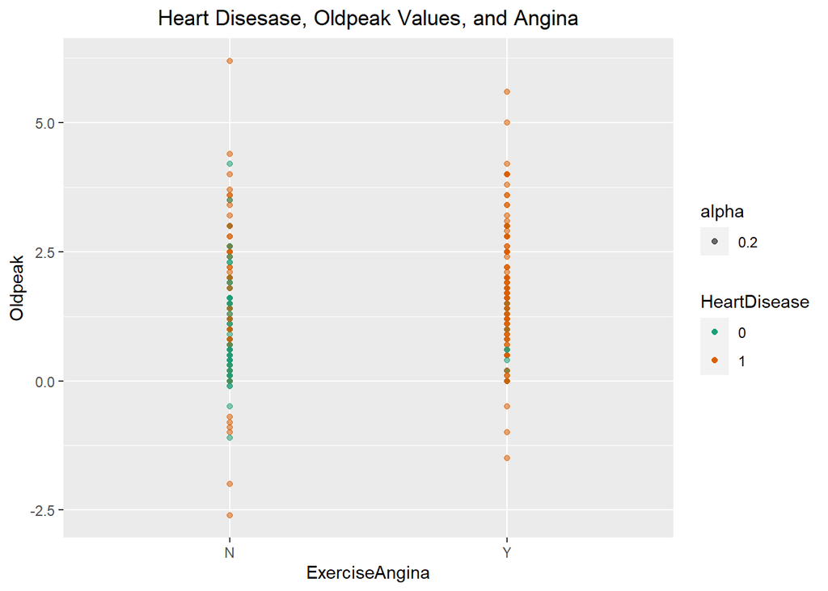

This chart shows the comparison between the “Old Peak”, or ST elevation peak, and the existence of chest pain (angina) with exercise, and whether that patient was diagnosed with heart disease.

It appears that more patients with heart disease did experience chest pain, with a peak of around 1.25 being the median of the majority of those with both chest pain and heart disease.

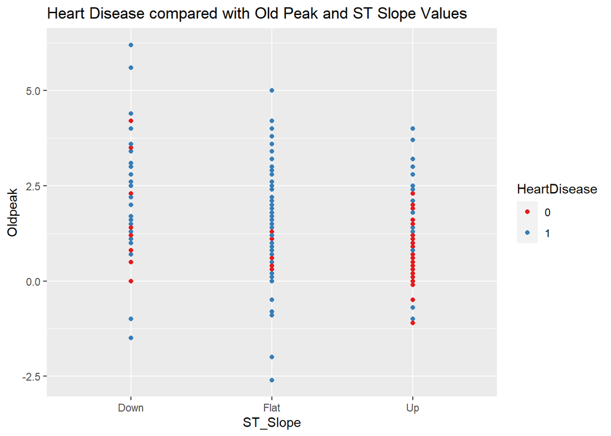

Since there was a strong negative correlation between some of these variables, I wanted to review their relationships. ST Slopes of “Up” seem to have a higher concentration of negative heart disease diagnosis, and a lower “Oldpeak” value than the average that did have heart disease and chest pain in the prior visual.

ST Slopes of Flat seem to have the highest concentration of heart disease patients, and the value of the Oldpeak is consistent with our prior visualization, as would be expected.

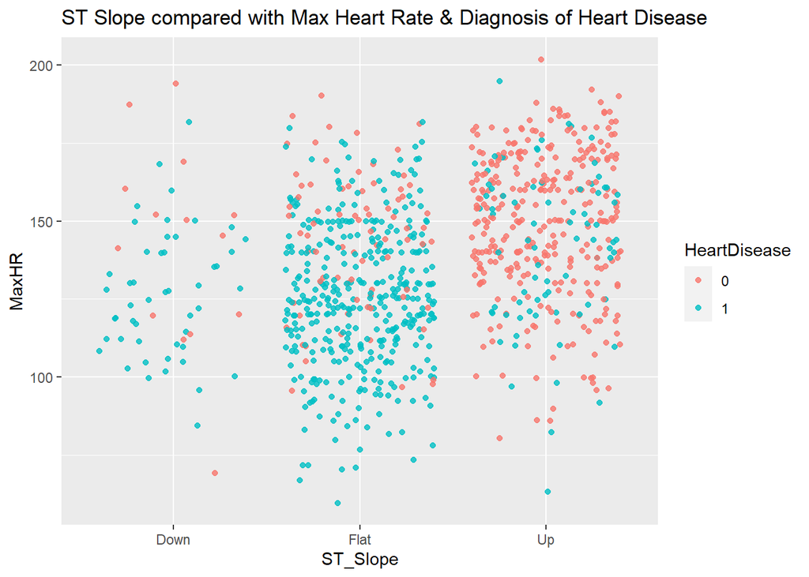

It’s clear that ST Slopes of Flat seem to have the highest concentration of positive heart disease findings, with a rather well-distributed value for Max Heart Rate.

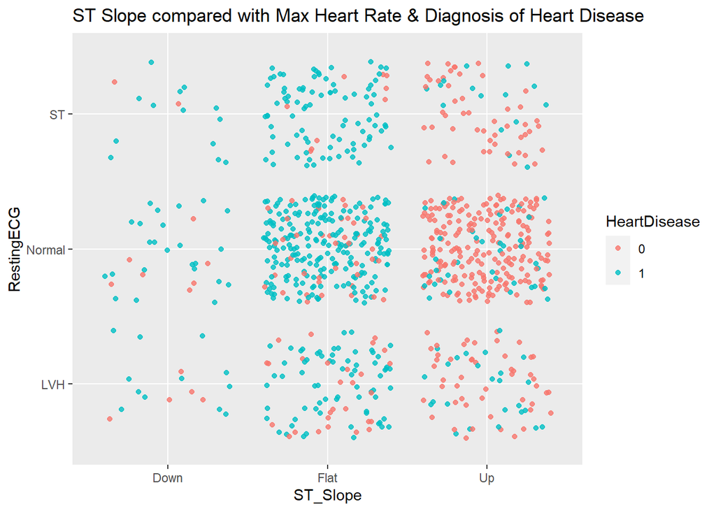

I thought this was a very interesting view, comparing ST slope and ECG readings, and showing where positive and negative heart disease diagnoses lie. There is a heavy concentration of Flat ST Slopes with Normal ECG readings and a positive heart disease diagnosis in those patients.

# Multivariate Analysis

Based on the correlations and relationships above, I decided to compare several combinations of variables along with heart disease. Most patients with heart disease experienced chest pain. Old Peak values, though correlated strongly, did not vary greatly between those with chest pain and those without. It looks as though the values are only slightly higher on average.

Lastly, there is a heavy concentration of Flat ST Slopes with Normal ECG readings and a positive heart disease diagnosis in those patients.

# Final Review and Summary

### Correlation Matrix

The correlation between variables is a strong lead toward further analysis that can be done, so I wanted to include this in my final summary.

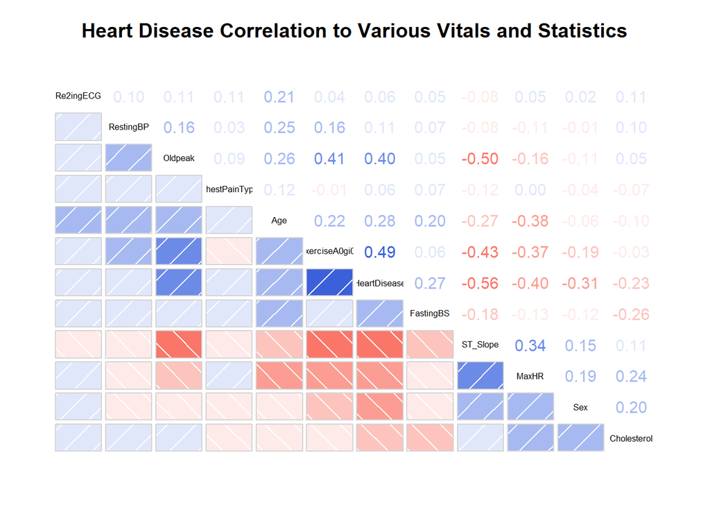

# Correlation Matrix Notes

The correlation matrix above shows dark blue for strong positive correlation, and dark red for strong negative correlation. I’ve updated so there are numbers to illustrate the correlation along with the color shades.

The labels exist in the spaces where the matrix items would intersect with themselves, forming the diagonal. This is a great overall view of the data set and correlations between pairs of variables.

### Heart Disease compared to ECG & ST Values

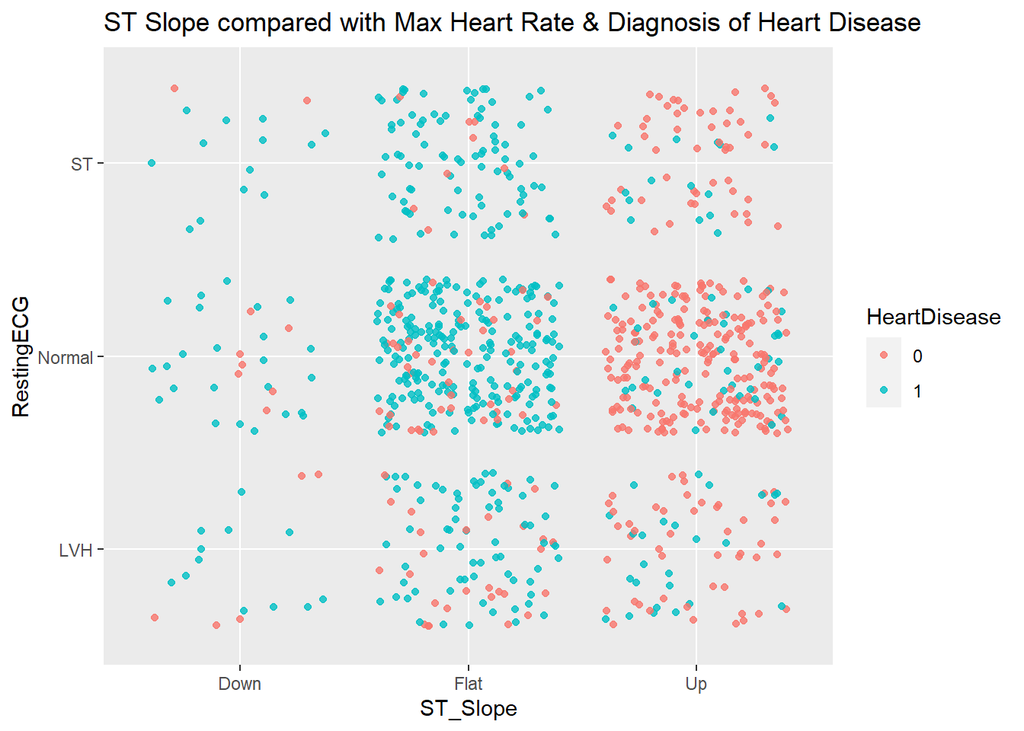

### Findings

There is a heavy concentration of Flat ST Slopes with Normal ECG readings and a positive heart disease diagnosis in those patients. There is a similar concentration of negative heart disease findings in the Normal ECG range with a slope value of “Up”.

### Heart Disease & Gender

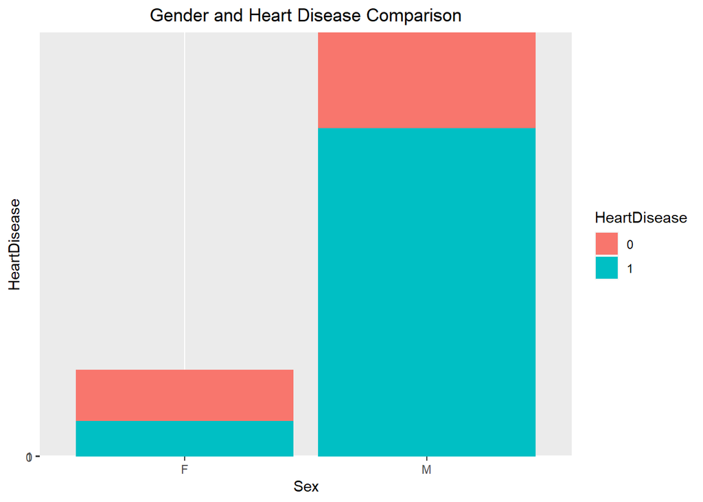

### Gender Analysis

It can be assumed that gender, based on the visual, will weigh slightly toward a positive diagnosis in males when this data is run through a model. The male population was much greater, so it would be interesting to have more data on female patients to see if the distribution of a larger sample remained the same.

# Reflection

Of all the features in the dataset, there were a few that in practical application will be strongly correlated with heart disease diagnosis. Of these, I believe that ST slope, Exercise Angina, Old Peak, and gender will be some of the strongest predictors. As mentioned above, a larger sample set could possibly confirm this to be true, especially in the female sample set.

It is helpful to have real world data and studies that have been done, many on the relationships of these factors to heart disease, heart attacks, and related issues. Studies have backed some of the findings of this analysis.

It would be very helpful to have a larger data set to confirm whether female patients have the same nearly equal split in positive or negative diagnoses.

## References:

R Cookbook: http://www.cookbook-r.com/

R Bloggers: https://www.r-bloggers.com/

Quick-R: https://www.statmethods.net/advgraphs/correlograms.html

Fedesoriano. (2021). Heart Failure Prediction Dataset. Kaggle. https://www.kaggle.com/fedesoriano/heart-failure-prediction.

Mayo Clinic Staff. (n.d.). Heart Disease. May Clinic. https://www.mayoclinic.org/diseases-conditions/heart-disease/symptoms-causes/\  
syc-20353118

Wilson, Peter W. F.. (12 May 1998). Prediction of Coronary Heart Disease Using Risk Factor Categories. American Heart Association Journals. https://www.ahajournals.org/doi/10.1161/01.CIR.97.18.1837